# SOM4 - Reading and ploting Confocal data

Paixao et al. 2021. The Middle Paleolithic Ground Stones Tools of Nesher Ramla Unit V (Southern Levant): a multi-scale use-wear approach for assessing the assemblage functional variability. Quaternary International

2021-04-07 12:08:02

**Brief description of the script**

This R markdown document reads, summarizes and plots data for: *Paixao et al. 2021. The Middle Paleolithic Ground Stones Tools of Nesher Ramla Unit V (Southern Levant): a multi-scale use-wear approach for assessing the assemblage functional variability. Quaternary International*

The document contains includes plots of the quantitative surface texture analysis, using Confocal microcopy.

This R project and respective scripts follow the procedures described by Marwick et al. 2017.

The authors would like to thank Ivan Calandra and Lisa Schunk for their help and contribution on several chunks of code included here in the script (pieces of code are also adapated from Calandra et al. 2019, Pedergnana et al. 2020a, 2020b).

To compile this markdown document do not delete or move files from their original folders. Please note that most of the tables and figures in this file do not match the numbering in the PhD dissertation manuscript.

For any questions, comments and inputs, please contact:

Eduardo Paixão, paixao@rgzm.de

# Load data into R project

*Imported files are in: ‘../analysis/raw_data’*

*Figures are saved in: ‘../analysis/plots’*

*Tables are saved in: ‘../analysis/derived_data’*

```r
# Load required libraries

library(tidyverse)
library(utils)
library(knitr)
library(janitor)
library(kableExtra)
library(GGally)
library(doBy)
library(ggpubr)
library(tools)

# See your WD and update the following paths
# getwd()

# Load data from .csv
confocaldataarch <- read.delim("../raw_data/confocalarch/confocaldataarch.csv", header = T, ";")

data_file <- list.files("../raw_data/confocalarch", pattern = "\\.csv$", full.names = TRUE)
md5_in <- md5sum(data_file)
info_in <- data.frame(file = basename(names(md5_in)), checksum = md5_in, row.names = NULL)
```

# Confocal micro surface texture data

## Import and summarize data

```r
# compute descriptive statistics

nminmaxmeanmedsd <- function(x){
    y <- x[!is.na(x)]
    n_test <- length(y)
    min_test <- min(y)
    max_test <- max(y)
    mean_test <- mean(y)
    med_test <- median(y)
    sd_test <- sd(y)
    out <- c(n_test, min_test, max_test, mean_test, med_test, sd_test)
    names(out) <- c("n", "min", "max", "mean", "median", "sd")
    return(out)
}

num.var <- 21:length(confocaldataarch)

confostatsarch <- summaryBy(.~sample + workedmaterial, data=confocaldataarch[c("sample", "workedmaterial", names(confocaldataarch)[num.var])], FUN=nminmaxmeanmedsd)

write_csv(confostatsarch, "../derived_data/confocalstats_arch.csv")
```

## Plot all paramaters

```r
# Sample main dataset
# Only archaeological tools

confoarch <- filter(confocaldataarch, sample == "archaeological")

# Loop for plotting all surface texture parameters

for (i in num.var) cat("[",i,"] ", names(confoarch)[i], "\n", sep = "")
```

```
## [21] Sq
## [22] Ssk
## [23] Sku
## [24] Sp
## [25] Sv
## [26] Sz
## [27] Sa
## [28] Smr
## [29] Smc
## [30] Sxp
## [31] Sal
## [32] Str
## [33] Std
## [34] Sdq
## [35] Sdr
```

[output cut: 19 more lines]

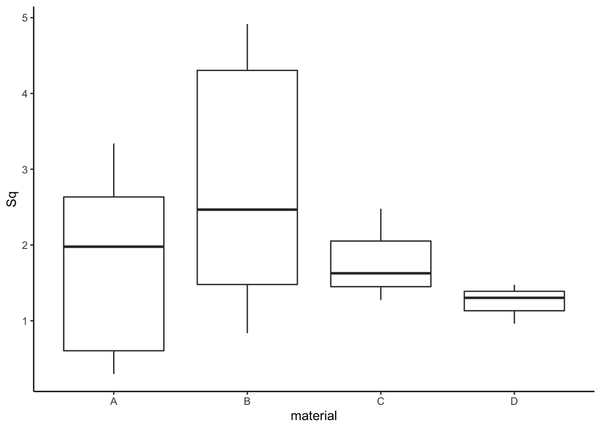

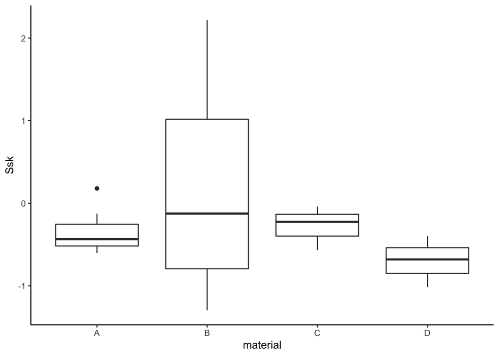

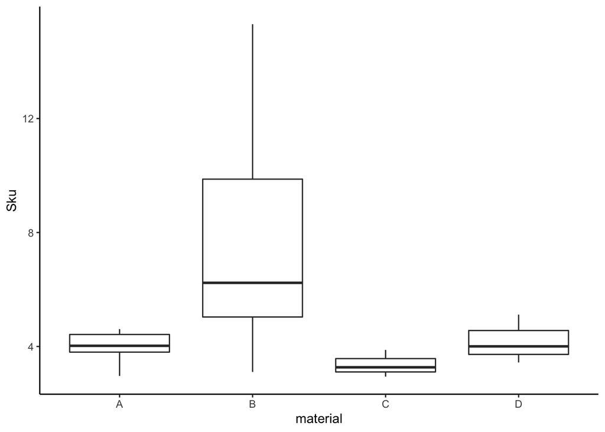

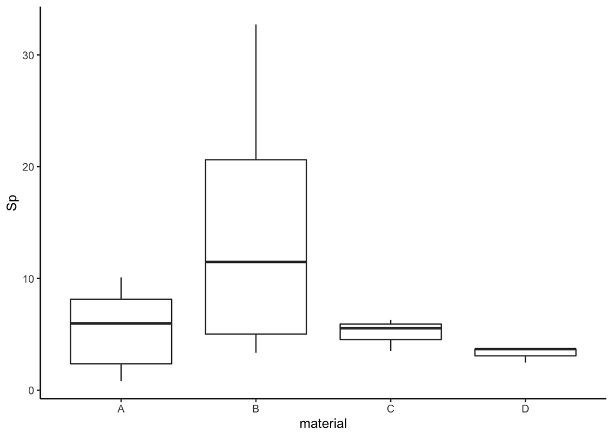

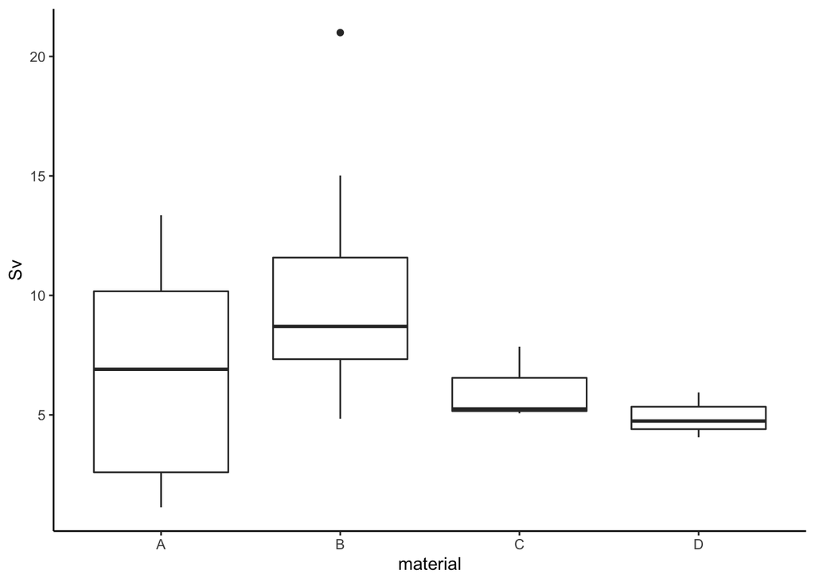

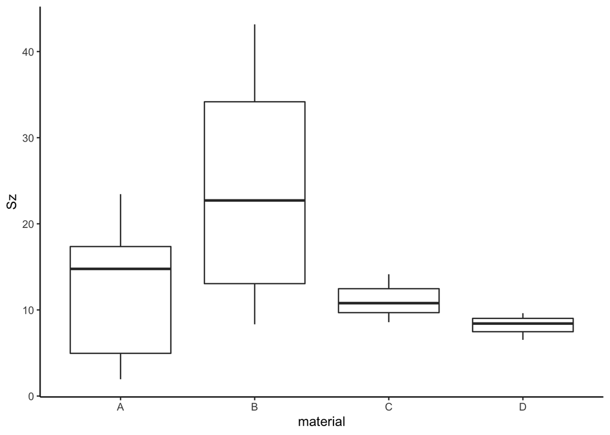

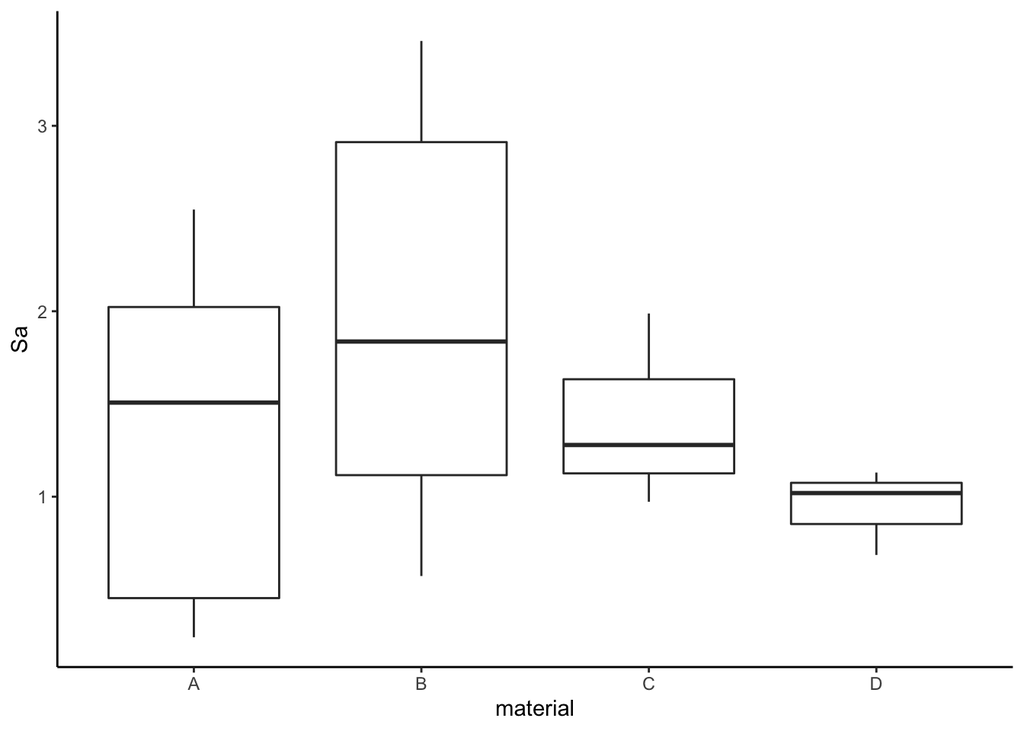

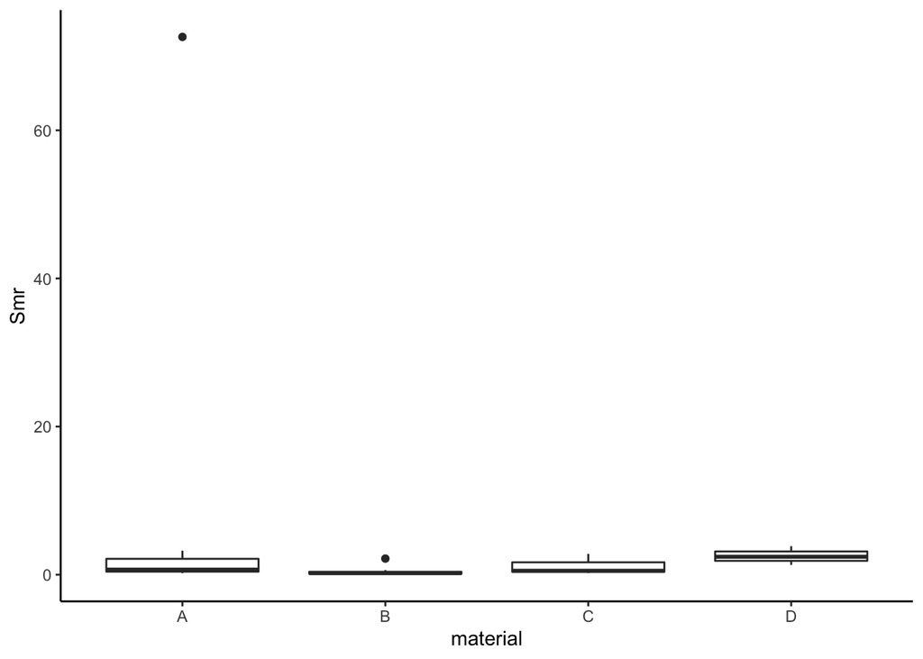

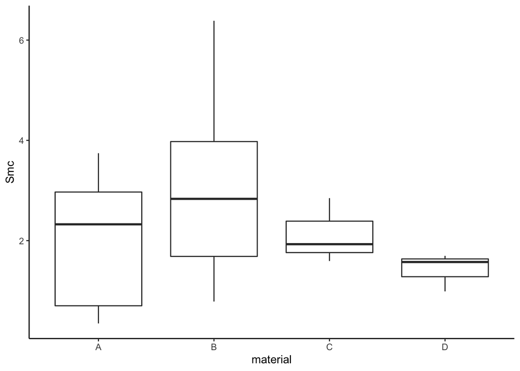

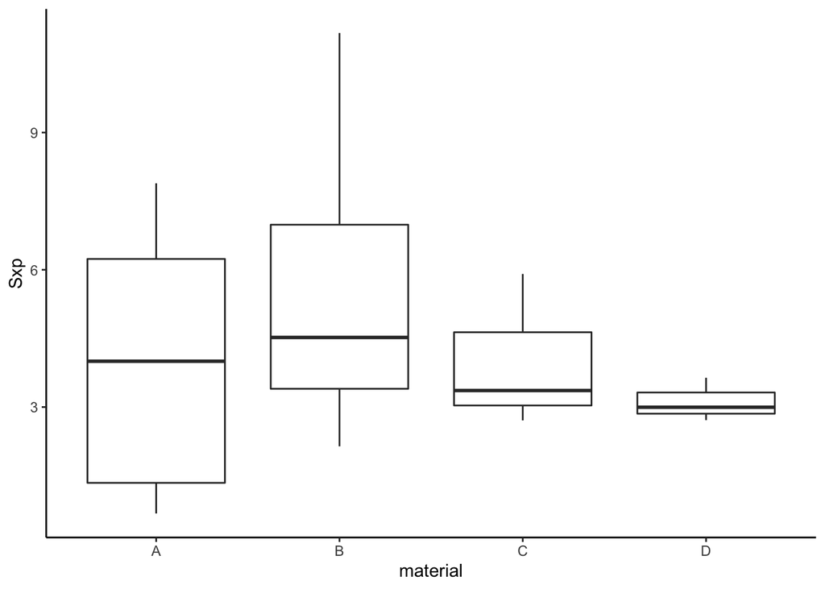

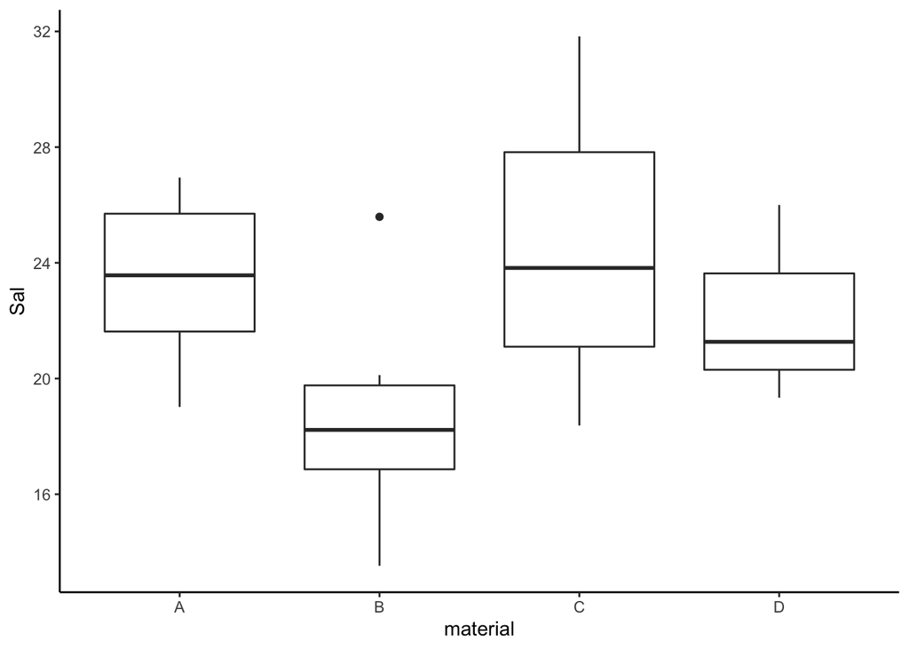

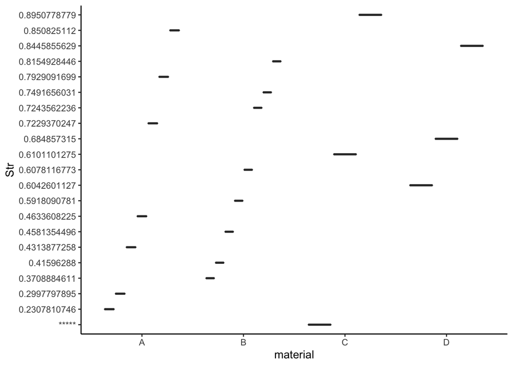

[22 more figures not shown]

```r
for (i in num.var) {
  p <- ggplot(data = confocaldataarch, aes_string(x = "workedmaterial", y = names(confoarch)[i])) +
         geom_boxplot() +
         # geom_line(aes(group = motion)) +
         theme_classic() +
         # facet_wrap(~ sample) +
         labs(x = "material", y = gsub("\\.", " ", names(confoarch)[i])) +
         scale_colour_hue(h = c(25,225))
  print(p)

  # saves the plots
  file_out <- paste0(file_path_sans_ext(info_in[["file"]]), "_plot_",
                       names(confoarch)[i], ".pdf")
    ggsave(filename = file_out, plot = p, path = "../plots", device = "pdf", width = 26,
           height = 21, units = "cm" )
}
```

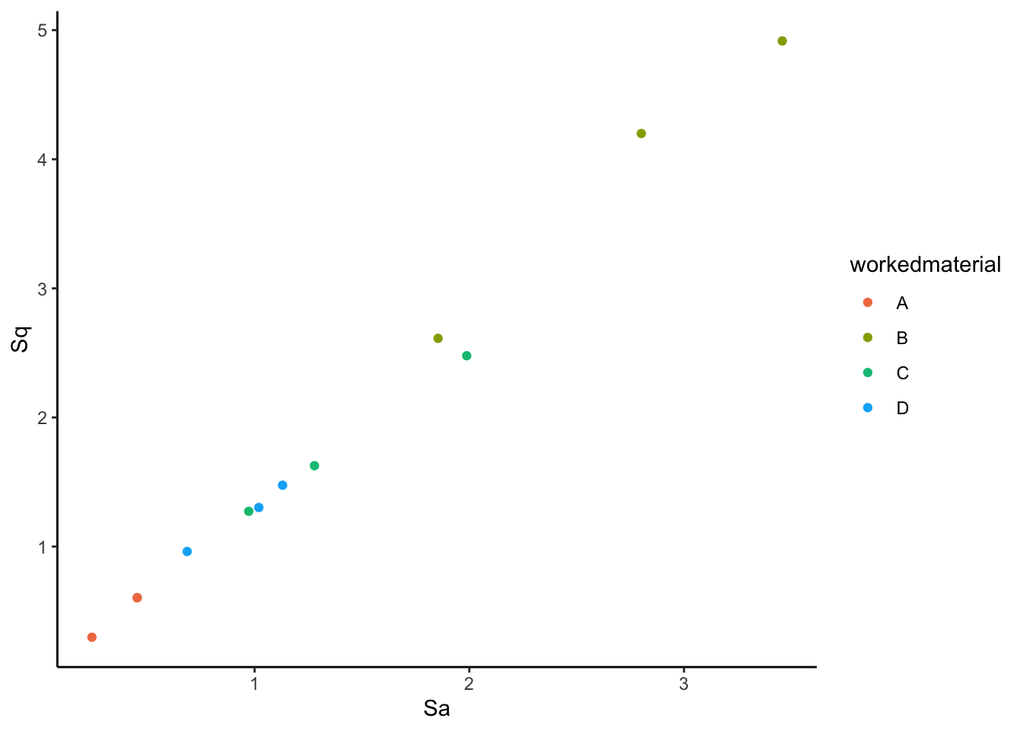

```r
# Only archaeological
# Sa vs. Sq

Sa_Sq <- ggplot(data = confoarch) +
         geom_point(mapping = aes(x = Sa, y = Sq, colour = workedmaterial)) +
         theme_classic() +
         labs(colour = "workedmaterial") +
          scale_colour_hue(h = c(25, 230))
print(Sa_Sq)
```

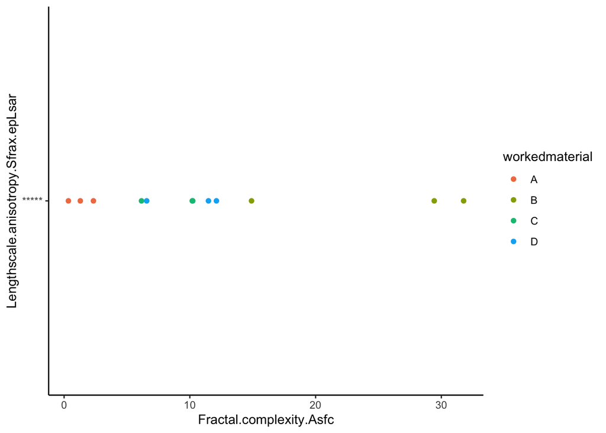

```r
file_out <- paste0(file_path_sans_ext(info_in[["file"]]), "_scatterplot_Sa-Sq", ".pdf")
ggsave(filename = file_out, plot = Sa_Sq, path = "../plots", device = "pdf")
# epLsar vs. Asfc

ep_As <- ggplot(data = confoarch) +
         geom_point(mapping = aes(x = Fractal.complexity.Asfc, y = Lengthscale.anisotropy.Sfrax.epLsar, colour = workedmaterial)) +
         theme_classic() +
         labs(colour = "workedmaterial") +
         scale_colour_hue(h = c(25, 230))
print(ep_As)
```

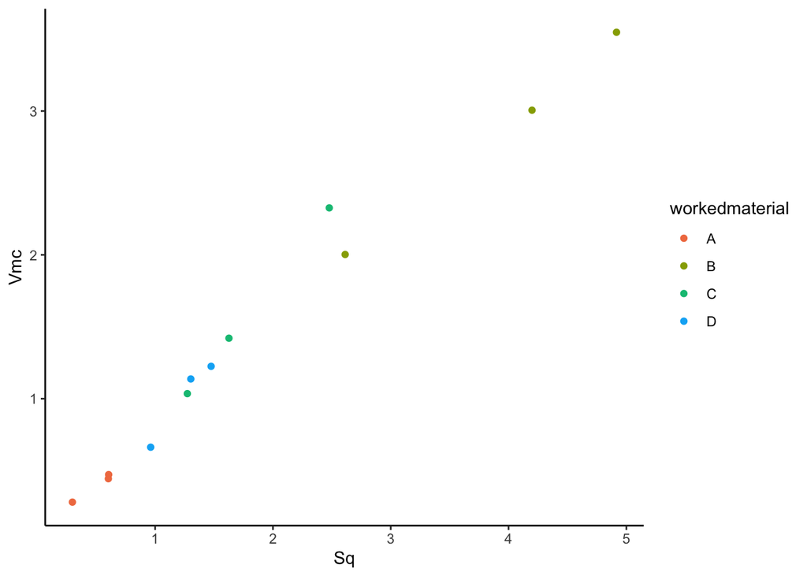

```r
file_out <- paste0(file_path_sans_ext(info_in[["file"]]), "_scatterplot_Asfc-epLsar", ".pdf")
ggsave(filename = file_out, plot = ep_As, path = "../plots", device = "pdf")
# Sq vs. Vmc

Sq_Vmc <- ggplot(data = confoarch) +
          geom_point(mapping = aes(x = Sq, y = Vmc, colour = workedmaterial)) +
          theme_classic() +
          labs(colour = "workedmaterial") +
          scale_colour_hue(h = c(25, 230))
print(Sq_Vmc)
```

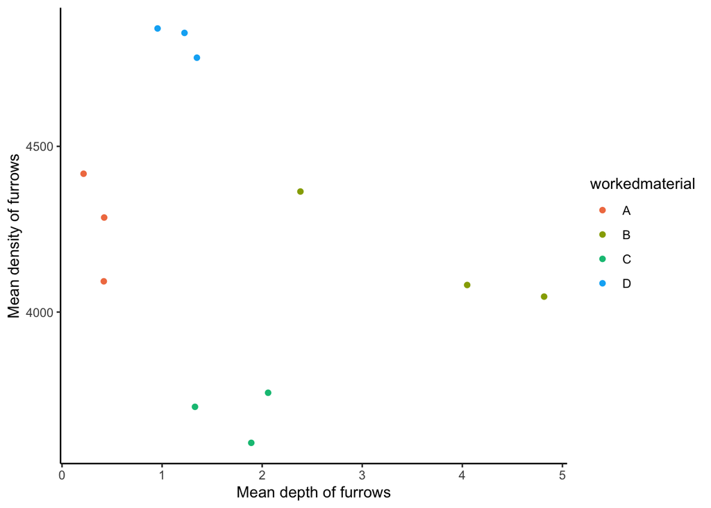

```r
file_out <- paste0(file_path_sans_ext(info_in[["file"]]), "_scatterplot_Sq-Vmc", ".pdf")
ggsave(filename = file_out, plot = Sq_Vmc, path = "../plots", device = "pdf")
# Mean depth of furrows vs. mean density of furrows

furrows <- ggplot(data = confoarch) +
           geom_point(mapping = aes(x = Mean.depth.of.furrows, y = Mean.density.of.furrows,
                                    colour = workedmaterial)) +
           theme_classic() +
           labs(colour = "workedmaterial", x = "Mean depth of furrows", y = "Mean density of furrows") +
           scale_colour_hue(h = c(25, 230))
print(furrows)
```

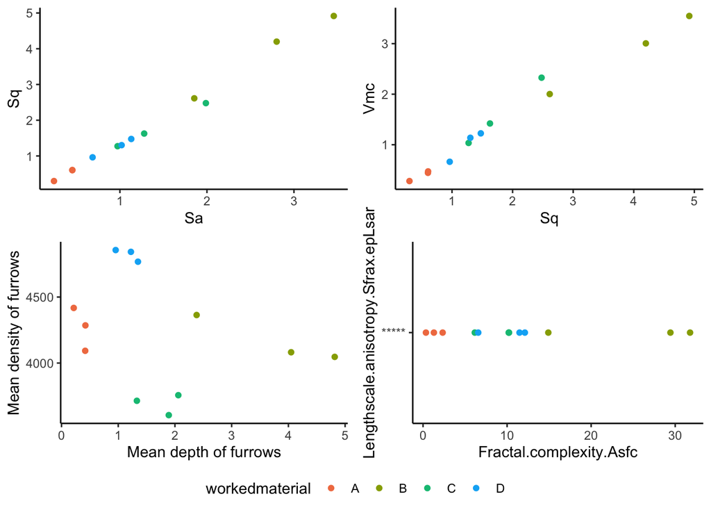

```r
file_out <- paste0(file_path_sans_ext(info_in[["file"]]), "_scatterplot_furrows", ".pdf")
ggsave(filename = file_out, plot = furrows, path = "../plots", device = "pdf")
# combine all in a single image

ggarrange(Sa_Sq, Sq_Vmc, furrows, ep_As, common.legend = TRUE, legend = "bottom")
```

```r
ggsave("../plots/scatterplots.png")
```

## Scatterplot matrix for the ISO 25178 Area scale, Height and volume parameters

```r
data(confocaldataarch, package = "reshape")
data(confoarch, package = "reshape")
```

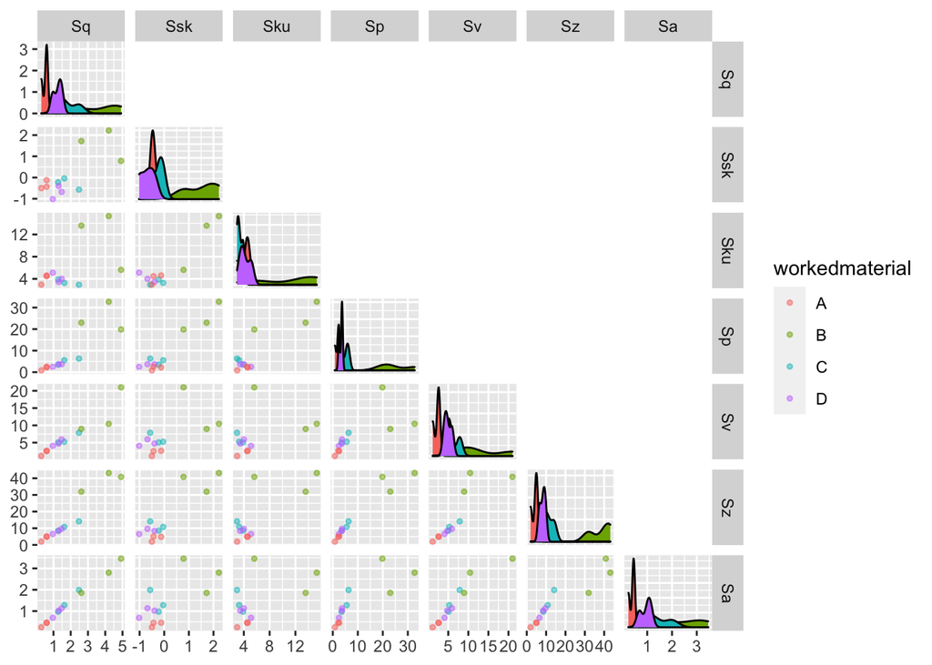

```r
# Only archaeological
# Height parameters

ggpairs(data=confoarch,
        columns = c(21:27),
        cardinality_threshold = 30,
        mapping = ggplot2::aes(color = workedmaterial),
        lower = list(continuous = wrap("points", alpha = 0.5, size = 1)),
        upper = list(continuous = "blank"),
        legend = c(2,1)
        ) +

    theme(legend.position = "right") +
  labs(fill = "Micro polish type")
```

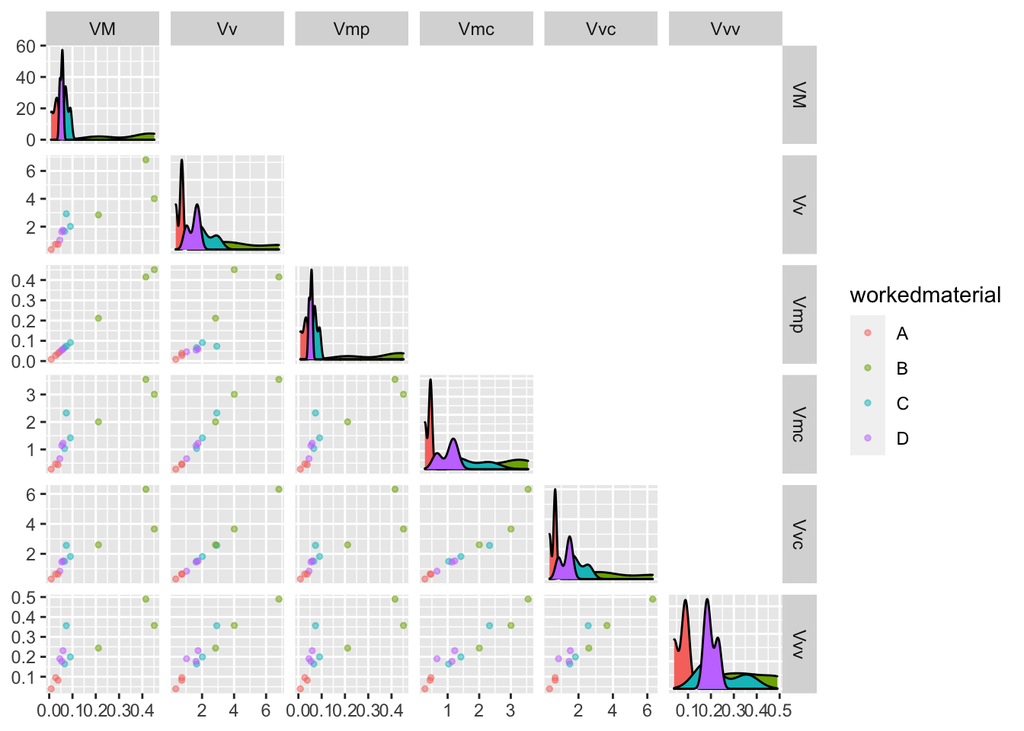

```r
ggsave("../plots/confocalarcharea_matrix.png")
# Volume parameters

ggpairs(data=confoarch,
        columns = c(36:41),
        cardinality_threshold = 30,
        mapping = ggplot2::aes(color = workedmaterial),
        lower = list(continuous = wrap("points", alpha = 0.5, size = 1)),
        upper = list(continuous = "blank"),
        legend = c(2,1)
        ) +

    theme(legend.position = "right") +
  labs(fill = "Micro polish type")
```

```r
ggsave("../plots/confocalarchvolume_matrix.png")
```

## Plot confostats for the ISO 25178 Area-scale, Height and volume parameters

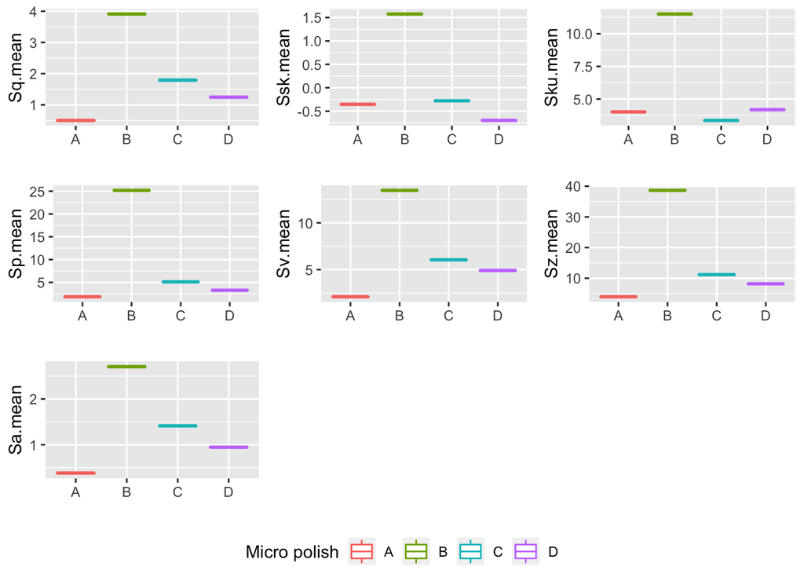

```r
# select parameter from dataset

# Only archaeological

confostatsarch2 <- filter(confostatsarch, sample == "archaeological")


heightconfostats <- select(confostatsarch2,workedmaterial, Sq.mean,Ssk.mean,Sku.mean,Sp.mean,Sv.mean,Sz.mean,Sa.mean)

p1 <- ggplot(heightconfostats, aes(x=workedmaterial, y=Sq.mean, colour=workedmaterial)) +
  geom_boxplot() +
  labs(x="", colour="Micro polish")

p2 <- ggplot(heightconfostats, aes(x=workedmaterial, y=Ssk.mean, colour=workedmaterial)) +
  geom_boxplot() +
  labs(x="", colour="Micro polish")

p3 <- ggplot(heightconfostats, aes(x=workedmaterial, y=Sku.mean, colour=workedmaterial)) +
  geom_boxplot() +
  labs(x="", colour="Micro polish")

p4 <- ggplot(heightconfostats, aes(x=workedmaterial, y=Sp.mean, colour=workedmaterial)) +
  geom_boxplot() +
  labs(x="", colour="Micro polish")

p5 <- ggplot(heightconfostats, aes(x=workedmaterial, y=Sv.mean, colour=workedmaterial)) +
  geom_boxplot() +
  labs(x="", colour="Micro polish")

p6 <- ggplot(heightconfostats, aes(x=workedmaterial, y=Sz.mean, colour=workedmaterial)) +
  geom_boxplot() +
  labs(x="", colour="Micro polish")

p7 <- ggplot(heightconfostats, aes(x=workedmaterial, y=Sa.mean, colour=workedmaterial)) +
  geom_boxplot() +
  labs(x="", colour="Micro polish")

ggarrange(p1, p2, p3, p4, p5, p6, p7, common.legend = TRUE, font.label = list(size=8), legend="bottom")
```

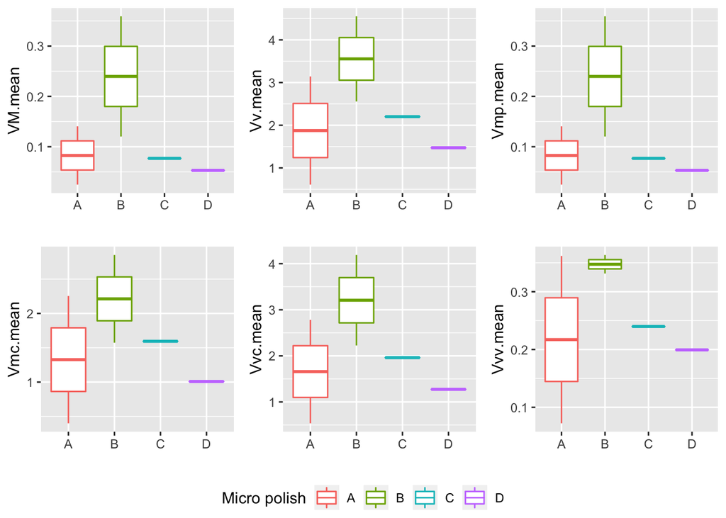

```r
ggsave("../plots/confostatsarcharea_boxplots.png")
# Now Volume parameters

volumeconfostats <- select(confostatsarch,sample,workedmaterial, VM.mean,Vv.mean,Vmp.mean,Vmc.mean,Vvc.mean,Vvv.mean)

p8 <- ggplot(volumeconfostats, aes(x=workedmaterial, y=VM.mean, colour=workedmaterial)) +
  geom_boxplot() +
  labs(x="", colour="Micro polish")

p9 <- ggplot(volumeconfostats, aes(x=workedmaterial, y=Vv.mean, colour=workedmaterial)) +
  geom_boxplot() +
  labs(x="", colour="Micro polish")

p10 <- ggplot(volumeconfostats, aes(x=workedmaterial, y=Vmp.mean, colour=workedmaterial)) +
  geom_boxplot() +
  labs(x="", colour="Micro polish")

p11 <- ggplot(volumeconfostats, aes(x=workedmaterial, y=Vmc.mean, colour=workedmaterial)) +
  geom_boxplot() +
  labs(x="", colour="Micro polish")

p12 <- ggplot(volumeconfostats, aes(x=workedmaterial, y=Vvc.mean, colour=workedmaterial)) +
  geom_boxplot() +
  labs(x="", colour="Micro polish")

p13 <- ggplot(volumeconfostats, aes(x=workedmaterial, y=Vvv.mean, colour=workedmaterial)) +
  geom_boxplot() +
  labs(x="", colour="Micro polish")

ggarrange(p8, p9, p10, p11, p12, p13, common.legend = TRUE, font.label = list(size=8), legend="bottom")
```

```r
ggsave("../plots/confostatarchvolume_boxplots.png")
```